# lab_2_Soshnikova

3.Асимптотична складність :  
Алгоритм сортування вставлянням  
Найкращий випадок: 𝑂(𝑛) – коли вихідний список вже відсортований, і  
кожен новий елемент вставляється безпосередньо за останнім елементом.  
Найгірший випадок: 𝑂(𝑛2) – коли вихідний список відсортований у  
зворотному порядку, і для кожного елементу потрібно перебрати усі попередні  
елементи, щоб вставити його на потрібне місце  
Алгоритм сортування бульбашкою  
У найкращому випадку, коли масив вже відсортований, бульбашкове сортування може завершити  
виконання після першого проходу, якщо алгоритм реалізований з перевіркою на наявність  
перестановок (тобто, якщо на жодному проході не було змін, алгоритм припиняє виконання). У цьому випадку кількість операцій складає: 𝑂(𝑛)  
У найгіршому випадку (коли масив відсортований у зворотному порядку),  
кожен елемент на кожному проході потрібно буде порівняти з кожним іншим елементом.  
Отже, складність алгоритму в найгіршому випадку: 𝑂(𝑛2)

```python
def bubble_sort(arr):
    n = len(arr)
    for i in range(n):
        # Введемо змінну flag для перевірки, чи були перестановки
        swapped = False
        # Проходимо по всіх елементах, крім останніх i елементів (вони вже відсортовані)
        for j in range(0, n-i-1):
            # Якщо поточний елемент більший за наступний, міняємо їх місцями
            if arr[j] > arr[j+1]:
                arr[j], arr[j+1] = arr[j+1], arr[j]
                swapped = True
        # Якщо за проходу не було жодної перестановки, масив вже відсортований
        if not swapped:
            break
    return arr

# Приклад використання
arr = [64, 34, 25, 12, 22, 11, 90]
print("Невідсортований масив:", arr)
sorted_arr = bubble_sort(arr)
print("Відсортований масив:", sorted_arr)
```

```
Невідсортований масив: [64, 34, 25, 12, 22, 11, 90]
Відсортований масив: [11, 12, 22, 25, 34, 64, 90]
```

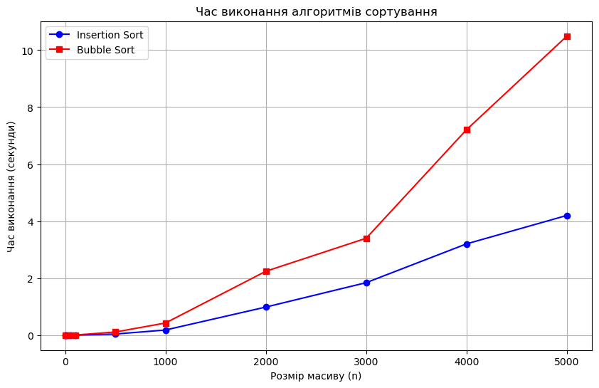

```python
import time
import random
import matplotlib.pyplot as plt
# Алгоритм сортування методом вставки
def insertion_sort(arr):
    n = len(arr)
    for i in range(1, n):
        key = arr[i]
        j = i - 1
        while j >= 0 and arr[j] > key:
            arr[j + 1] = arr[j]
            j -= 1
        arr[j + 1] = key

# Алгоритм сортування методом бульбашки
def bubble_sort(arr):
    n = len(arr)
    for i in range(n):
        swapped = False
        for j in range(0, n - i - 1):
            if arr[j] > arr[j + 1]:
                arr[j], arr[j + 1] = arr[j + 1], arr[j]
                swapped = True
        if not swapped:
            break

# Функція для вимірювання часу сортування
def measure_time(sort_function, arr):
    start_time = time.time()
    sort_function(arr)
    return time.time() - start_time

# Масиви розміром n=[5, 10, 50, 100, 500, 1000, 2000, 3000, 4000, 5000, 10000, 20000, 50000, 100000]
sizes = [5, 10, 50, 100, 500, 1000, 2000, 3000, 4000, 5000]

# Списки для зберігання часів
times_insert = []
times_bubble = []

# Вимірювання часу для кожного розміру масиву
for n in sizes:
    arr_insert = random.sample(range(1, n*10), n)
    arr_bubble = arr_insert.copy()

    # Виміряємо час для сортування методом вставки
    time_insert = measure_time(insertion_sort, arr_insert)
    times_insert.append(time_insert)

    # Виміряємо час для сортування методом бульбашки
    time_bubble = measure_time(bubble_sort, arr_bubble)
    times_bubble.append(time_bubble)

# Побудова графіків
plt.figure(figsize=(10, 6))
plt.plot(sizes, times_insert, label='Insertion Sort', marker='o', color='b')
plt.plot(sizes, times_bubble, label='Bubble Sort', marker='s', color='r')
plt.xlabel('Розмір масиву (n)')
plt.ylabel('Час виконання (секунди)')
plt.title('Час виконання алгоритмів сортування')
plt.legend()
plt.grid(True)
plt.show()
```

7  
1 ) О-нотація використовується для опису верхньої межі складності функції або алгоритму,  
тобто, як найгірше може змінюватися час або простір алгоритму при збільшенні розміру вхідних даних.  
Вона визначає максимальне зростання функції і є основним способом оцінки складності алгоритмів у найгіршому випадку.  
Омега-нотація навпаки описує нижню межу для функції, тобто вона визначає, як мінімум функція зростатиме при великих значеннях 𝑛.  
Це дозволяє оцінити найкращий випадок або мінімальну складність алгоритму.  
2)У найкращому випадку (коли масив уже відсортований), алгоритм сортування методом вставки буде просто порівнювати кожен елемент з попереднім  
і не виконуватиме жодних зсувів елементів. Тобто кожне порівняння буде відбуватися лише один раз для кожного елемента.  
Для кожного елемента (від другого до останнього) буде лише одне порівняння з попереднім елементом.  
Оскільки зсуви не виконуються, то час, витрачений на кожне порівняння, — це 𝑂(1).  
Таким чином, часова складність алгоритму в найсприятливішому випадку — це лінійна складність 𝑂(𝑛), де 𝑛 — кількість елементів у масиві.  
3)Ефективний алгоритм — це алгоритм, який вирішує задачу з оптимальним використанням ресурсів,  
таких як час і пам'ять, і здатний працювати з великими обсягами даних, зберігаючи коректність та надійність.  
4)Головний параметр (розмір) задачі — це кількість або характеристика вхідних даних, яка визначає складність задачі.  
Він є основним індикатором того, скільки ресурсів (часу та пам'яті) може бути необхідно для вирішення цієї задачі.  
У контексті алгоритмів і складності, розмір задачі зазвичай вимірюється за кількістю елементів у вхідних даних або  
за іншими параметрами, які прямо впливають на час або простір, необхідний для обробки цих даних.  
5)F(n)=n3+7n2-14n g(n)=O(n3) O(g(n))=n3 n3+7n2-14n<=cn3 n3+7n2-14n<=n3+7n3-14n3 n0=1 c=-6